# xwMOOC 데이터 시각화

왜 아프리카인가?

xwMOOC

2018-07-10

# 1 설문조사로부터 받은 영감

Max Richman(2015)은 뉴욕 R 컨퍼런스에서 “R for Every Survey Analysis”라는 주제로 약 20분에 걸친 발표를 진행했다. 본인 일도 소개하면서 “왜 아프리카인가?”라는 설명을 하면서 카토그램(Cartogram)으로 인구가 급격히 증가하는 아프리카대륙을 시각화하였다. 이와 더불어 위험성에 대한 부분도 언급하면서 설문조사(survey)의 중요성과 함께 R로 데이터를 분석하는 방법을 소개하고 있다.

[video not shown]

# 2 세계인구 변화 카토그램

세계인구 변화에 대한 카토그램을 애니메이션으로 작성하기 위해서는 데이터와 지도가 필요하고 이를 조작해서 변환시킬 수 있는 프로그래밍언어가 필요하다. 세계인구에 대한 연도별 공신력있는 데이터는 [세계은행 API](http://data.worldbank.org/developers/api-overview)에서 가져오는데 [`wbstats`](https://cran.r-project.org/web/packages/wbstats/) 팩키지가 그 역할을 수행하는데 적합하고, 세계지도는 `geojson` 파일을 [GitHub, “johan/world.geo.json”](https://github.com/johan/world.geo.json)에서 직접 가져오는 방식도 있지만 [Natural World](https://www.naturalearthdata.com/) 지도 데이터셋을 [`rnaturalearth`](https://cran.r-project.org/web/packages/rnaturalearth/index.html) 팩키지를 통해 가져오는 것도 가능하다.

[figure not shown]

## 2.1 세계인구 데이터

`wbsearch()` 함수를 통해 세계인구 데이터를 검색해서 `SP.POP.TOTL`이라는 것을 확인하고 `countrycode()` 팩키지를 통해 국가명만 발라낸다.

```r
# 0. 환경설정 -----
library(tidyverse)
library(wbstats)
library(countrycode)

# 1. 세계 인구 데이터 가져오기 -----
pop_vars <- wbsearch(pattern = "Population")

# pop_vars %>%
#  filter(str_detect(indicator, '(?=total)')) %>%
#  filter(indicatorID == 'SP.POP.TOTL')

world_pop_dat <- wb(indicator = "SP.POP.TOTL", startdate = 1950, enddate = 2017)

# 2. 국가별 인구만 추출 -----
world_pop_df <- world_pop_dat %>%
  mutate(country_filter = countrycode(world_pop_dat$iso3c, 'iso3c', 'country.name')) %>%
  filter(!is.na(country_filter)) %>%
  as_tibble()

world_pop_df %>%
  sample_n(100) %>%
  DT::datatable()
```

|  | iso3c | date | value | indicatorID | indicator | iso2c | country | country_filter |
| --- | --- | --- | --- | --- | --- | --- | --- | --- |
| 1 | SLB | 2006 | 481422 | SP.POP.TOTL | Population, total | SB | Solomon Islands | Solomon Islands |
| 2 | GRC | 1987 | 10000595 | SP.POP.TOTL | Population, total | GR | Greece | Greece |
| 3 | SYC | 2008 | 86956 | SP.POP.TOTL | Population, total | SC | Seychelles | Seychelles |
| 4 | MNP | 1960 | 10035 | SP.POP.TOTL | Population, total | MP | Northern Mariana Islands | Northern Mariana Islands |
| 5 | MOZ | 1995 | 15759132 | SP.POP.TOTL | Population, total | MZ | Mozambique | Mozambique |
| 6 | AFG | 1989 | 11777609 | SP.POP.TOTL | Population, total | AF | Afghanistan | Afghanistan |
| 7 | VEN | 2004 | 26327225 | SP.POP.TOTL | Population, total | VE | Venezuela, RB | Venezuela |
| 8 | EST | 1984 | 1518617 | SP.POP.TOTL | Population, total | EE | Estonia | Estonia |
| 9 | ABW | 1963 | 56695 | SP.POP.TOTL | Population, total | AW | Aruba | Aruba |
| 10 | MOZ | 1992 | 14071231 | SP.POP.TOTL | Population, total | MZ | Mozambique | Mozambique |

[output cut: 90 more lines]

## 2.2 세계지도 데이터 - 첫번째 방법

`sf` 팩키지를 지도데이터를 다루는 핵심 팩키지로 상정하고 세계지도는 `geojson` 파일을 [GitHub, “johan/world.geo.json”](https://github.com/johan/world.geo.json) 사이트에서 받아온다. 그리고, 사전에 파악한 국가코드 `iso3c`를 기준으로 인구데이터를 조합해서 2017년 인구데이터를 단계구분도(Choropleth map)로 시각화해서 테스트한다.

```r
# 0. 환경설정 -----
library(sf)

# 1. 데이터 -----
## 1.1. 세계 인구 데이터 가져오기 -----
# world_pop_df

# 1.2. 지도  -----
# download.file(url="https://raw.githubusercontent.com/johan/world.geo.json/master/countries.geo.json", destfile = "data/world_map.geojson")

world_sf <- st_read("data/world_map.geojson")
```

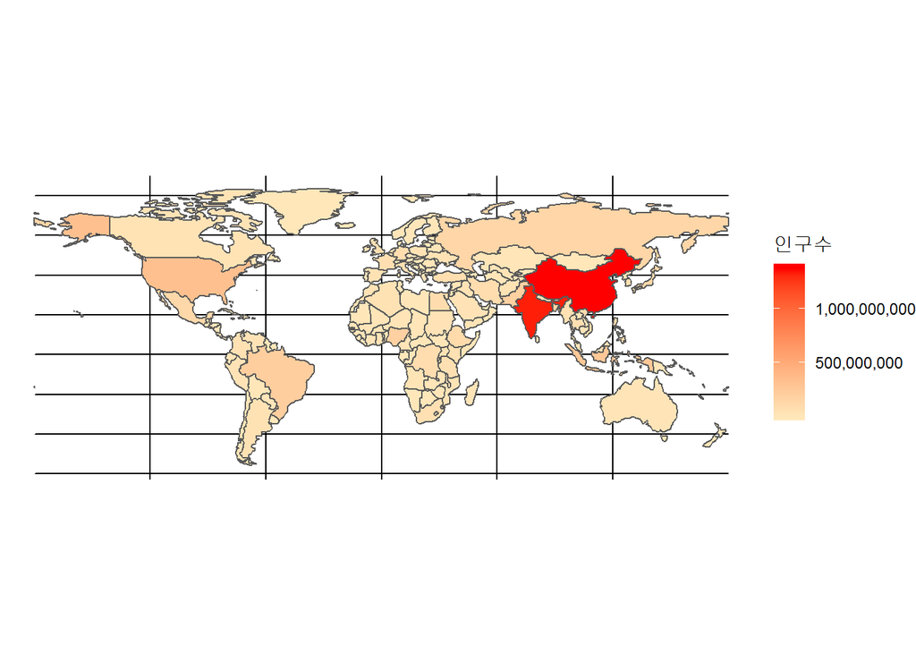

```r
# 1.3. 데이터 병합  -----
world_df_sf <- inner_join(world_sf, world_pop_df, by=c("id" = "iso3c"))

# 2. 단계구분도(Choropleth) 인구 -----

world_df_sf %>%
  filter(date == 2017) %>%
  ggplot(aes(fill=value)) +
    geom_sf() +
    theme_void() +
    scale_fill_gradient(low = "wheat1", high = "red", name = "인구수", labels = scales::comma)
```

## 2.3 세계지도 데이터 - 두번째 방법

두번째 방법은 첫번째와 유사하지만 `rnaturalearth` 팩키지 `ne_countries()` 함수를 통해 세계지도를 가져와서 이를 `sp` 자료형에서 `sf` 자료형으로 변환시킨다. 그리고 나서 국가코드를 기준으로 매칭하고 이를 단계구분도로 1960년만 시각화한다.

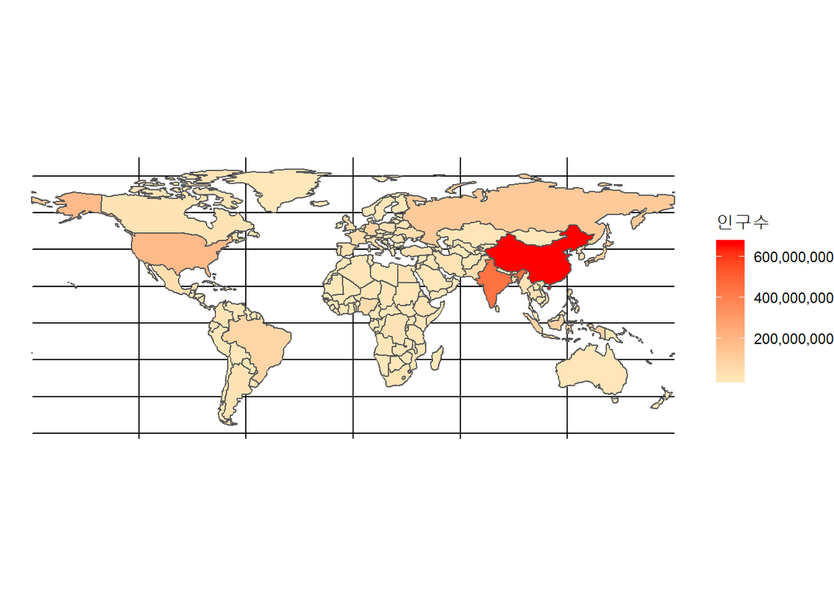

```r
# 0. 환경설정 -----
library(rnaturalearth)

# 1. 세계지도 데이터 -----
## 1.1. 세계 인구 데이터 가져오기 -----
# world_pop_df

# 1.2. 지도  -----
world_map <- ne_countries(type = 'countries', scale = 'small')
world_map_sf <- sf::st_as_sf(world_map)

# 1.3. 데이터 병합  -----
world_df_sf <- inner_join(world_map_sf, world_pop_df, by=c("iso_a3" = "iso3c"))

# 2. 단계구분도(Choropleth) 인구 -----
## 2.1. 정적 인구 그래프
world_df_sf %>%
  filter(date == 1960) %>%
  ggplot(aes(fill=value)) +
  geom_sf() +
  theme_void() +
  scale_fill_gradient(low = "wheat1", high = "red", name = "인구수", labels = scales::comma)
```

## 2.4 세계 인구 애니메이션

`gganimate` 팩키지를 바탕으로 `date` 연도를 바꿔 이를 애니메이션으로 변환시킨다.

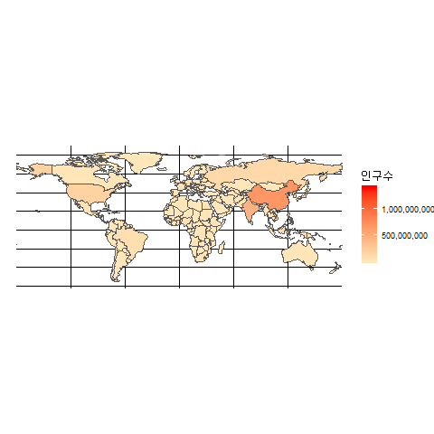

```r
# 0. 환경설정 -----
library(gganimate)

world_pop_ani <- ggplot(world_df_sf, aes(fill=value)) +
    geom_sf() +
    theme_void() +
    scale_fill_gradient(low = "wheat1", high = "red", name = "인구수", labels = scales::comma) +
    transition_manual(date)

animate(world_pop_ani, 100, 10)
```

## 2.5 세계인구 변량비례도(Cartogram)

`cartogram` 팩키지 `cartogram_cont()` 함수로 변량비례도를 그린다. 현재, `cartogram_cont()` 함수를 실행시켜면 수렴하지 않는 문제가 있어 추후 해결하기로 한다.

```r
# 0. 환경설정 -----
library(cartogram)

# 3. 변량비례도(變量比例圖, Cartogram) 지도 -----
world_pop_2016_cart <- world_df_sf %>%
  filter(date == 2016)

world_pop_1960_cart <- cartogram_cont(world_pop_1960_cart, weight = 'value',  prepare = "remove")

world_pop_1960_cart  %>%
  ggplot(aes(fill=value)) +
  geom_sf() +
  theme_void() +
  scale_fill_gradient(low = "wheat1", high = "red", name = "인구수", labels = scales::comma)
```